# Dərs 2: Lineer Bərabərləşdirmə Metodları

Təhsildə Test Nəticələrinin Bərabərləşdirilməsi - R Proqram Dili ilə

Test Bərabərləşdirmə Kursu

2025-07-15

# 1 Xətti Bərabərləşdirmə Metodlarına Giriş

## 1.1 Dərsin Məqsədləri

Bu dərsin sonunda siz:

✅ Xətti bərabərləşdirmənin riyazi əsaslarını başa düşəcəksiniz  
✅ R-də xətti bərabərləşdirmə funksiyalarını yarada biləcəksiniz  
Xətti bərabərləşdirmənin üstünlük və məhdudiyyətlərini öyrənəcəksiniz  
✅ Real test məlumatları üzərində xətti bərabərləşdirmə həyata keçirə biləcəksiniz  
✅ Bərabərləşdirmə keyfiyyətini qiymətləndirə biləcəksiniz

## 1.2 Nəzəri Əsaslar

### 1.2.1 Xətti Bərabərləşdirmənin Mahiyyəti

Xətti bərabərləşdirmə test nəticələrini çevirmək üçün ən sadə və geniş istifadə olunan metoddur. Bu metod iki testin **ortalama** və **standart sapma** statistikalarına əsaslanır.

### 1.2.2 Riyazi Formula

Xətti bərabərləşdirmə üçün əsas formula:

$$Y = a + bX$$

burada: - $Y$ = bərabərləşdirilmiş bal (Test Y şkalasında) - $X$ = orijinal bal (Test X şkalasında)  
- $a$ = sabit (intercept) - $b$ = əmsal (slope)

### 1.2.3 Parametrlərin Hesablanması

**Slope (b):**
$$b =
\frac{SD_Y}{SD_X}$$

**Intercept (a):**
$$a =
\bar{Y} - b \cdot \bar{X}$$

burada: - $\bar{X}, \bar{Y}$ = müvafiq testlərin ortalama balları - $SD_X, SD_Y$ = müvafiq testlərin standart sapmaları

## 1.3 R Mühitinin Hazırlanması

### 1.3.1 Paketlərin Yüklənməsi

```r
# Lazım olan paketləri yükləyək
suppressMessages({
  library(equate)      # Test bərabərləşdirmə
  library(ggplot2)     # Vizuallaşdırma
  library(dplyr)       # Məlumat manipulyasiyası
  library(knitr)       # Cədvəl formatlaşdırması
  library(plotly)      # İnteraktiv qrafiklər
  library(gridExtra)   # Çox panelli qrafiklər
  library(psych)       # Psixometrik təhlil
  library(scales)      # Alpha funksiyası üçün
})

# Əvvəlki dərsdən məlumatları yükləyək
if (file.exists("lesson1_data.RData")) {
  load("lesson1_data.RData")
  cat("✅ Əvvəlki dərsdən məlumatlar yükləndi\n")
} else {
  # Əgər faylı tapmasa, yenidən yaradırıq
  set.seed(123)
  test_A <- data.frame(
    student_id = 1:300,
    score = round(rnorm(300, mean = 75, sd = 12), 0),
    form = "A"
  )

  set.seed(456)
  test_B <- data.frame(
    student_id = 301:580,
    score = round(rnorm(280, mean = 78, sd = 10), 0),
    form = "B"
  )
  cat("ℹ️  Yeni məlumatlar yaradıldı\n")
}
```

```
## ℹ️  Yeni məlumatlar yaradıldı
```

```r
# Rəngli palitra
colors_custom <- c("#3498db", "#e74c3c", "#2ecc71", "#f39c12", "#9b59b6")
```

### 1.3.2 İlkin Məlumat Təhlili

```r
# Test A və Test B məlumatlarının əsas statistikaları
stats_A <- list(
  n = nrow(test_A),
  mean = mean(test_A$score),
  sd = sd(test_A$score),
  min = min(test_A$score),
  max = max(test_A$score)
)

stats_B <- list(
  n = nrow(test_B),
  mean = mean(test_B$score),
  sd = sd(test_B$score),
  min = min(test_B$score),
  max = max(test_B$score)
)

cat("=== TEST A STATİSTİKALARI ===\n")
```

```
## === TEST A STATİSTİKALARI ===
```

```r
cat("Şagird sayı:", stats_A$n, "\n")
```

```
## Şagird sayı: 300
```

```r
cat("Ortalama:", round(stats_A$mean, 2), "\n")
```

```
## Ortalama: 75.41
```

```r
cat("Standart sapma:", round(stats_A$sd, 2), "\n")
```

```
## Standart sapma: 11.36
```

```r
cat("Minimum:", stats_A$min, "\n")
```

```
## Minimum: 47
```

```r
cat("Maksimum:", stats_A$max, "\n\n")
```

```
## Maksimum: 114
```

```r
cat("=== TEST B STATİSTİKALARI ===\n")
```

```
## === TEST B STATİSTİKALARI ===
```

```r
cat("Şagird sayı:", stats_B$n, "\n")
```

```
## Şagird sayı: 280
```

```r
cat("Ortalama:", round(stats_B$mean, 2), "\n")
```

```
## Ortalama: 78.29
```

```r
cat("Standart sapma:", round(stats_B$sd, 2), "\n")
```

```
## Standart sapma: 9.82
```

```r
cat("Minimum:", stats_B$min, "\n")
```

```
## Minimum: 54
```

```r
cat("Maksimum:", stats_B$max, "\n")
```

```
## Maksimum: 101
```

## 1.4 Xətti Bərabərləşdirmənin Tətbiqi

### 1.4.1 Addım-addım Həyata Keçirilməsi

#### 1.4.1.1 Addım 1: Parametrlərin Hesablanması

```r
# Xətti bərabərləşdirmə parametrlərini hesablayaq
# Test A-nı Test B şkalasına çevirmək üçün

# Slope (b) hesablanması
b_coefficient <- stats_B$sd / stats_A$sd

# Intercept (a) hesablanması
a_coefficient <- stats_B$mean - b_coefficient * stats_A$mean

cat("=== LİNEER BƏRABƏRLƏŞDİRMƏ PARAMETRLƏRİ ===\n")
```

```
## === LİNEER BƏRABƏRLƏŞDİRMƏ PARAMETRLƏRİ ===
```

```r
cat("Slope (b):", round(b_coefficient, 4), "\n")
```

```
## Slope (b): 0.8643
```

```r
cat("Intercept (a):", round(a_coefficient, 4), "\n\n")
```

```
## Intercept (a): 13.1079
```

```r
cat("Transformasiya tənliyi: Y =", round(a_coefficient, 2),
    "+", round(b_coefficient, 3), "* X\n")
```

```
## Transformasiya tənliyi: Y = 13.11 + 0.864 * X
```

#### 1.4.1.2 Addım 2: Transformasiya Funksiyasının Yaradılması

```r
# Xətti transformasiya funksiyası
linear_transform <- function(x_scores, a, b) {
  transformed_scores <- a + b * x_scores
  return(transformed_scores)
}

# Test A ballarını Test B şkalasına çevirmək
test_A_transformed <- linear_transform(test_A$score, a_coefficient, b_coefficient)

# Nəticələri test_A dataframe-inə əlavə edək
test_A$score_transformed <- round(test_A_transformed, 1)

# İlk 10 nəticəni göstərək
comparison_sample <- data.frame(
  Student_ID = test_A$student_id[1:10],
  Original_Score = test_A$score[1:10],
  Transformed_Score = test_A$score_transformed[1:10],
  Difference = test_A$score_transformed[1:10] - test_A$score[1:10]
)

kable(comparison_sample,
      caption = "Xətti Transformasiyanın Nümunə Nəticələri (İlk 10 şagird)",
      digits = 2)
```

Xətti Transformasiyanın Nümunə Nəticələri (İlk 10 şagird)

| Student_ID | Original_Score | Transformed_Score | Difference |
| --- | --- | --- | --- |
| 1 | 68 | 71.9 | 3.9 |
| 2 | 72 | 75.3 | 3.3 |
| 3 | 94 | 94.4 | 0.4 |
| 4 | 76 | 78.8 | 2.8 |
| 5 | 77 | 79.7 | 2.7 |
| 6 | 96 | 96.1 | 0.1 |
| 7 | 81 | 83.1 | 2.1 |
| 8 | 60 | 65.0 | 5.0 |
| 9 | 67 | 71.0 | 4.0 |
| 10 | 70 | 73.6 | 3.6 |

#### 1.4.1.3 Addım 3: Vizual Təqdimat

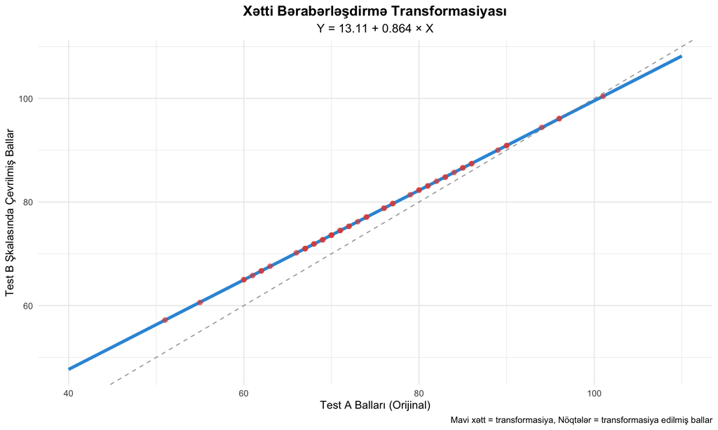

Xətti bərabərləşdirmənin vizual təqdimatı

```r
# Transformasiya xəttinin çəkilməsi
score_range <- seq(40, 110, 1)
transformed_range <- linear_transform(score_range, a_coefficient, b_coefficient)

# Xətti transformasiya qrafiki
ggplot() +
  geom_line(aes(x = score_range, y = transformed_range),
            color = colors_custom[1], linewidth = 1.5) +
  geom_point(aes(x = test_A$score[1:50], y = test_A$score_transformed[1:50]),
             alpha = 0.6, color = colors_custom[2], size = 2) +
  geom_abline(intercept = 0, slope = 1, linetype = "dashed",
              color = "gray50", alpha = 0.7) +
  labs(
    title = "Xətti Bərabərləşdirmə Transformasiyası",
    subtitle = paste("Y =", round(a_coefficient, 2), "+", round(b_coefficient, 3), "× X"),
    x = "Test A Balları (Orijinal)",
    y = "Test B Şkalasında Çevrilmiş Ballar",
    caption = "Mavi xətt = transformasiya, Nöqtələr = transformasiya edilmiş ballar"
  ) +
  theme_minimal() +
  theme(
    plot.title = element_text(hjust = 0.5, size = 14, face = "bold"),
    plot.subtitle = element_text(hjust = 0.5, size = 12)
  )
```

## 1.5 Müfəssəl Xətti Bərabərləşdirmə Funksiyası

### 1.5.1 Hərtərəfli Xətti Bərabərləşdirmə Funksiyası

```r
# Hərtərəfli Xətti bərabərləşdirmə funksiyası
linear_equating_comprehensive <- function(x_scores, y_scores,
                                        x_name = "Test X", y_name = "Test Y",
                                        return_details = TRUE) {

  # Əsas statistikalar
  n_x <- length(x_scores)
  n_y <- length(y_scores)

  mean_x <- mean(x_scores)
  mean_y <- mean(y_scores)

  sd_x <- sd(x_scores)
  sd_y <- sd(y_scores)

  # Xətti parametrlər
  b <- sd_y / sd_x
  a <- mean_y - b * mean_x

  # Transformasiya
  transformed_x <- a + b * x_scores

  # Keyfiyyət metrikləri
  # R-squared (X balları və transformasiya edilmiş X balları arasında)
  correlation <- cor(x_scores, transformed_x)

  # Standard Error of Equating (SEE)
  # Sadələşdirilmiş hesablama
  see <- sqrt(sd_y^2 * (1/n_x + 1/n_y))

  if (return_details) {
    # Ətraflı nəticələri qaytarın
    results <- list(
      # Parametrlər
      parameters = list(
        a = a,
        b = b
      ),

      # Statistikalar
      statistics = list(
        x_stats = list(n = n_x, mean = mean_x, sd = sd_x),
        y_stats = list(n = n_y, mean = mean_y, sd = sd_y)
      ),

      # Transformasiya edilmiş ballar
      transformed_scores = transformed_x,

      # Keyfiyyət metrikləri
      quality = list(
        correlation = correlation,
        see = see,
        mean_diff = mean(transformed_x) - mean_y,
        sd_diff = sd(transformed_x) - sd_y
      ),

      # Metadata
      metadata = list(
        x_name = x_name,
        y_name = y_name,
        method = "Linear Equating",
        date = Sys.Date()
      )
    )

    return(results)
  } else {
    # Sadə nəticələri qaytarın
    return(list(a = a, b = b, transformed = transformed_x))
  }
}

# Funksiyamızı test edək
linear_results <- linear_equating_comprehensive(
  test_A$score, test_B$score,
  "Test A", "Test B"
)

# Nəticələri göstərək
cat("=== LİNEER BƏRABƏRLƏŞDİRMƏ NƏTİCƏLƏRİ ===\n\n")
```

```
## === LİNEER BƏRABƏRLƏŞDİRMƏ NƏTİCƏLƏRİ ===
```

```r
cat("PARAMETRLƏRİ:\n")
```

```
## PARAMETRLƏRİ:
```

```r
cat("a (intercept):", round(linear_results$parameters$a, 3), "\n")
```

```
## a (intercept): 13.108
```

```r
cat("b (slope):", round(linear_results$parameters$b, 3), "\n\n")
```

```
## b (slope): 0.864
```

```r
cat("KEYFİYYƏT METRİKLƏRİ:\n")
```

```
## KEYFİYYƏT METRİKLƏRİ:
```

```r
cat("Korrelyasiya:", round(linear_results$quality$correlation, 3), "\n")
```

```
## Korrelyasiya: 1
```

```r
cat("SEE (Standard Error):", round(linear_results$quality$see, 3), "\n")
```

```
## SEE (Standard Error): 0.816
```

```r
cat("Ortalama fərqi:", round(linear_results$quality$mean_diff, 3), "\n")
```

```
## Ortalama fərqi: 0
```

```r
cat("SD fərqi:", round(linear_results$quality$sd_diff, 3), "\n")
```

```
## SD fərqi: 0
```

## 1.6 Praktiki Nümunələr

### 1.6.1 Nümunə 1: Dil Testləri

TOEFL və IELTS testlərinin bərabərləşdirilməsi nümunəsi:

```r
# TOEFL və IELTS testlərinin simulyasiyası
set.seed(2024)

# TOEFL balları (0-120 şkalası)
toefl_scores <- round(rnorm(500, mean = 85, sd = 15), 0)
toefl_scores <- pmax(0, pmin(120, toefl_scores))  # 0-120 aralığında məhdudlaşdır

# IELTS balları (0-9 şkalası)
ielts_scores <- round(rnorm(400, mean = 6.5, sd = 1.2), 1)
ielts_scores <- pmax(0, pmin(9, ielts_scores))  # 0-9 aralığında məhdudlaşdır

# Xətti bərabərləşdirmə
lang_equating <- linear_equating_comprehensive(
  toefl_scores, ielts_scores,
  "TOEFL", "IELTS"
)

# TOEFL-dan IELTS-ə çevirmə cədvəli
toefl_sample <- seq(60, 110, 10)
ielts_equivalent <- lang_equating$parameters$a +
                   lang_equating$parameters$b * toefl_sample

conversion_table <- data.frame(
  TOEFL_Score = toefl_sample,
  IELTS_Equivalent = round(ielts_equivalent, 1)
)

kable(conversion_table,
      caption = "TOEFL-dan IELTS-ə Xətti Çevirmə Cədvəli",
      col.names = c("TOEFL Balı", "IELTS Ekvivalenti"))
```

TOEFL-dan IELTS-ə Xətti Çevirmə Cədvəli

| TOEFL Balı | IELTS Ekvivalenti |
| --- | --- |
| 60 | 4.4 |
| 70 | 5.2 |
| 80 | 6.0 |
| 90 | 6.8 |
| 100 | 7.6 |
| 110 | 8.4 |

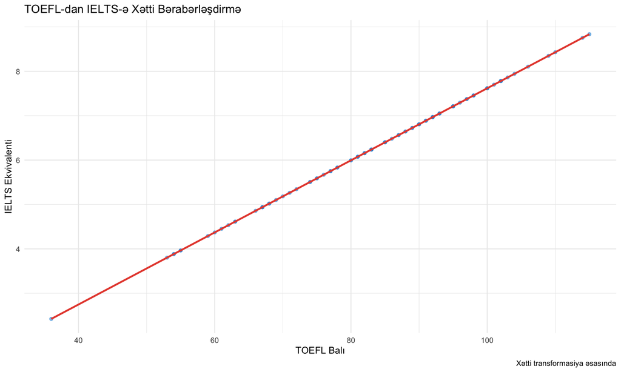

```r
# Vizuallaşdırma
ggplot() +
  geom_point(aes(x = toefl_scores[1:100],
                y = lang_equating$transformed_scores[1:100]),
            alpha = 0.6, color = colors_custom[1]) +
  geom_smooth(aes(x = toefl_scores[1:100],
                 y = lang_equating$transformed_scores[1:100]),
             method = "lm", se = FALSE, color = colors_custom[2]) +
  labs(
    title = "TOEFL-dan IELTS-ə Xətti Bərabərləşdirmə",
    x = "TOEFL Balı",
    y = "IELTS Ekvivalenti",
    caption = "Xətti transformasiya əsasında"
  ) +
  theme_minimal()
```

### 1.6.2 Nümunə 2: Universitetə Qəbul Testləri

```r
# Müxtəlif universitetlərin qəbul testləri
set.seed(789)

# Bakı Universitetinin testi
baku_uni_scores <- round(rnorm(600, mean = 480, sd = 70), 0)

# Gəncə Universitetinin testi
ganja_uni_scores <- round(rnorm(450, mean = 465, sd = 75), 0)

# Bərabərləşdirmə
uni_equating <- linear_equating_comprehensive(
  ganja_uni_scores, baku_uni_scores,
  "Gəncə Uni", "Bakı Uni"
)

cat("=== UNİVERSİTET TESTLƏRİNİN BƏRABƏRLƏŞDİRİLMƏSİ ===\n\n")
```

```
## === UNİVERSİTET TESTLƏRİNİN BƏRABƏRLƏŞDİRİLMƏSİ ===
```

```r
cat("Gəncə Uni testini Bakı Uni şkalasına çevirmək:\n")
```

```
## Gəncə Uni testini Bakı Uni şkalasına çevirmək:
```

```r
cat("Transformasiya tənliyi: Y =",
    round(uni_equating$parameters$a, 1), "+",
    round(uni_equating$parameters$b, 3), "× X\n\n")
```

```
## Transformasiya tənliyi: Y = 65.5 + 0.89 × X
```

```r
# Keçmə ballarının müqayisəsi
ganja_passing_scores <- c(350, 400, 450, 500)
baku_equivalent <- uni_equating$parameters$a +
                  uni_equating$parameters$b * ganja_passing_scores

passing_comparison <- data.frame(
  Ganja_Uni_Score = ganja_passing_scores,
  Baku_Uni_Equivalent = round(baku_equivalent, 0),
  Difference = round(baku_equivalent - ganja_passing_scores, 0)
)

kable(passing_comparison,
      caption = "Keçmə Ballarının Müqayisəsi",
      col.names = c("Gəncə Uni Balı", "Bakı Uni Ekvivalenti", "Fərq"))
```

Keçmə Ballarının Müqayisəsi

| Gəncə Uni Balı | Bakı Uni Ekvivalenti | Fərq |
| --- | --- | --- |
| 350 | 377 | 27 |
| 400 | 421 | 21 |
| 450 | 466 | 16 |
| 500 | 510 | 10 |

## 1.7 Xətti Bərabərləşdirmənin Həddləri və Fərziyyələri

### 1.7.1 Əsas Fərziyyələr

Xətti bərabərləşdirmə düzgün işləməsi üçün bir neçə fərziyyəyə ehtiyac duyur:

```r
# Fərziyyələrin yoxlanması

cat("=== LİNEER BƏRABƏRLƏŞDİRMƏ FƏRZİYYƏLƏRİNİN YOXLANMASI ===\n\n")
```

```
## === LİNEER BƏRABƏRLƏŞDİRMƏ FƏRZİYYƏLƏRİNİN YOXLANMASI ===
```

```r
# 1. Normal paylanma fərziyyəsi
# Shapiro test maksimum 5000 nümunə qəbul edir, bizim məlumatımız kiçikdir
sample_size_A <- min(length(test_A$score), 5000)
sample_size_B <- min(length(test_B$score), 5000)

shapiro_A <- shapiro.test(sample(test_A$score, sample_size_A))$p.value
shapiro_B <- shapiro.test(sample(test_B$score, sample_size_B))$p.value

cat("1. NORMAL PAYLANMA FƏRZİYYƏSİ:\n")
```

```
## 1. NORMAL PAYLANMA FƏRZİYYƏSİ:
```

```r
cat("Test A normal paylanma p-value:", round(shapiro_A, 4), "\n")
```

```
## Test A normal paylanma p-value: 0.0234
```

```r
cat("Test B normal paylanma p-value:", round(shapiro_B, 4), "\n")
```

```
## Test B normal paylanma p-value: 0.0705
```

```r
if (shapiro_A > 0.05 && shapiro_B > 0.05) {
  cat("✅ Normal paylanma fərziyyəsi təmin edilir\n\n")
} else {
  cat("⚠️  Normal paylanma fərziyyəsi pozulmuşdur\n\n")
}
```

```
## ⚠️  Normal paylanma fərziyyəsi pozulmuşdur
```

```r
# 2. Eyni variasiya fərziyyəsi (homoscedasticity)
var_ratio <- var(test_A$score) / var(test_B$score)
cat("2. VARİASİYA BƏRABƏRLİYİ:\n")
```

```
## 2. VARİASİYA BƏRABƏRLİYİ:
```

```r
cat("Variasiya nisbəti (A/B):", round(var_ratio, 3), "\n")
```

```
## Variasiya nisbəti (A/B): 1.339
```

```r
if (var_ratio >= 0.5 && var_ratio <= 2.0) {
  cat("✅ Variasiya bərabərliyi fərziyyəsi təmin edilir\n\n")
} else {
  cat("⚠️  Variasiya bərabərliyi fərziyyəsi pozulmuşdur\n\n")
}
```

```
## ✅ Variasiya bərabərliyi fərziyyəsi təmin edilir
```

```r
# 3. Paylanma formasının oxşarlığı
skew_A <- psych::skew(test_A$score)
skew_B <- psych::skew(test_B$score)

cat("3. PAYLANMA FORMASININ OXŞARLIĞI:\n")
```

```
## 3. PAYLANMA FORMASININ OXŞARLIĞI:
```

```r
cat("Test A çarpıqlığı:", round(skew_A, 3), "\n")
```

```
## Test A çarpıqlığı: 0.339
```

```r
cat("Test B çarpıqlığı:", round(skew_B, 3), "\n")
```

```
## Test B çarpıqlığı: -0.091
```

```r
cat("Çarpıqlıq fərqi:", round(abs(skew_A - skew_B), 3), "\n")
```

```
## Çarpıqlıq fərqi: 0.43
```

```r
if (abs(skew_A - skew_B) < 0.5) {
  cat("✅ Paylanma forması oxşarlığı təmin edilir\n\n")
} else {
  cat("⚠️  Paylanma forması əhəmiyyətli dərəcədə fərqlidir\n\n")
}
```

```
## ✅ Paylanma forması oxşarlığı təmin edilir
```

### 1.7.2 Xətti Bərabərləşdirmənin Məhdudiyyətləri

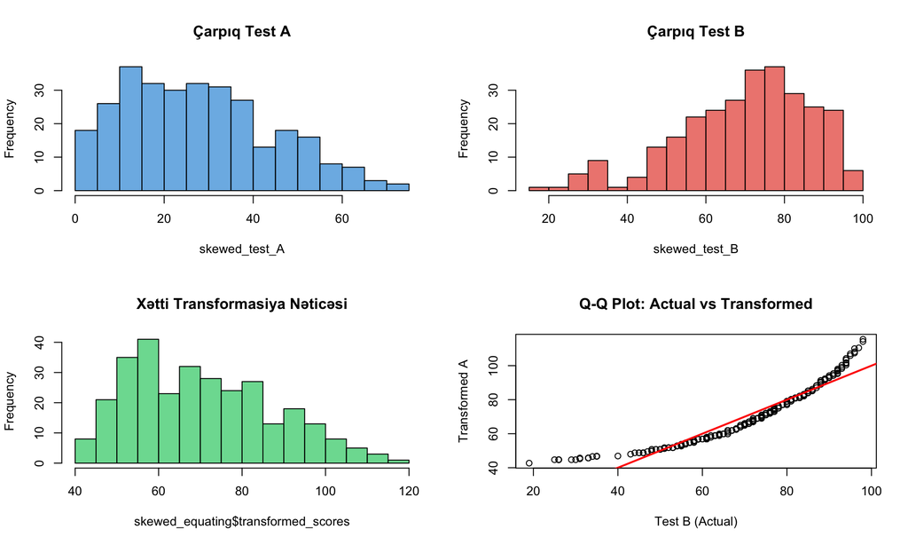

```r
# Çarpıq paylanmaların simulyasiyası - Xətti metodun məhdudiyyətləri
set.seed(999)

# Şiddətli çarpıq test məlumatları
skewed_test_A <- round(rbeta(300, 2, 5) * 100, 0)
skewed_test_B <- round(rbeta(280, 5, 2) * 100, 0)

# Xətti bərabərləşdirmə
skewed_equating <- linear_equating_comprehensive(
  skewed_test_A, skewed_test_B,
  "Çarpıq Test A", "Çarpıq Test B"
)

# Vizuallaşdırma - problemli halı göstərmək
par(mfrow = c(2, 2))

# Orijinal paylanmalar
hist(skewed_test_A, main = "Çarpıq Test A",
     col = scales::alpha(colors_custom[1], 0.7), breaks = 20)
hist(skewed_test_B, main = "Çarpıq Test B",
     col = scales::alpha(colors_custom[2], 0.7), breaks = 20)

# Xətti transformasiya nəticəsi
hist(skewed_equating$transformed_scores,
     main = "Xətti Transformasiya Nəticəsi",
     col = scales::alpha(colors_custom[3], 0.7), breaks = 20)

# Q-Q plot - uyğunsuzluğu göstərmək
qqplot(skewed_test_B, skewed_equating$transformed_scores,
       main = "Q-Q Plot: Actual vs Transformed",
       xlab = "Test B (Actual)", ylab = "Transformed A")
abline(0, 1, col = "red", lwd = 2)
```

```r
cat("=== ÇARPIQ PAYLANMALARDA LİNEER METODUN PROBLEMLƏRİ ===\n")
```

```
## === ÇARPIQ PAYLANMALARDA LİNEER METODUN PROBLEMLƏRİ ===
```

```r
cat("Çarpıq Test A çarpıqlığı:", round(psych::skew(skewed_test_A), 3), "\n")
```

```
## Çarpıq Test A çarpıqlığı: 0.476
```

```r
cat("Çarpıq Test B çarpıqlığı:", round(psych::skew(skewed_test_B), 3), "\n")
```

```
## Çarpıq Test B çarpıqlığı: -0.673
```

```r
cat("Transformasiya sonrası çarpıqlıq:",
    round(psych::skew(skewed_equating$transformed_scores), 3), "\n")
```

```
## Transformasiya sonrası çarpıqlıq: 0.476
```

```r
cat("⚠️  Xətti metod paylanma formasını düzgün ötürmür!\n")
```

```
## ⚠️  Xətti metod paylanma formasını düzgün ötürmür!
```

## 1.8 Keyfiyyət Qiymətləndirilməsi

### 1.8.1 Bərabərləşdirmə Keyfiyyətinin Ölçülməsi

```r
# Keyfiyyət qiymətləndirilməsi funksiyası
assess_equating_quality <- function(x_scores, y_scores, transformed_scores,
                                   method_name = "Linear") {

  # 1. Ortalama və SD uyğunluğu
  mean_target <- mean(y_scores)
  mean_transformed <- mean(transformed_scores)
  mean_diff <- abs(mean_target - mean_transformed)

  sd_target <- sd(y_scores)
  sd_transformed <- sd(transformed_scores)
  sd_diff <- abs(sd_target - sd_transformed)

  # 2. Paylanma uyğunluğu (Kolmogorov-Smirnov test)
  ks_test <- ks.test(y_scores, transformed_scores)

  # 3. Percentile uyğunluğu
  percentiles <- c(10, 25, 50, 75, 90)
  target_percentiles <- quantile(y_scores, percentiles/100)
  transformed_percentiles <- quantile(transformed_scores, percentiles/100)
  percentile_diffs <- abs(target_percentiles - transformed_percentiles)
  max_percentile_diff <- max(percentile_diffs)

  # 4. Root Mean Square Error (RMSE)
  # Eyni persentillər üçün
  common_percentiles <- seq(0.01, 0.99, 0.01)
  target_quantiles <- quantile(y_scores, common_percentiles)
  transformed_quantiles <- quantile(transformed_scores, common_percentiles)
  rmse <- sqrt(mean((target_quantiles - transformed_quantiles)^2))

  # Nəticələr
  quality_report <- list(
    method = method_name,
    mean_accuracy = mean_diff,
    sd_accuracy = sd_diff,
    ks_p_value = ks_test$p.value,
    max_percentile_diff = max_percentile_diff,
    rmse = rmse,
    overall_quality = ifelse(
      mean_diff < 1 && sd_diff < 1 && ks_test$p.value > 0.05,
      "Yaxşı",
      ifelse(mean_diff < 2 && sd_diff < 2, "Orta", "Zəif")
    )
  )

  return(quality_report)
}

# Test A-nın Test B-yə bərabərləşdirilməsinin keyfiyyəti
quality_results <- assess_equating_quality(
  test_A$score,
  test_B$score,
  linear_results$transformed_scores,
  "Linear Equating"
)

cat("=== BƏRABƏRLƏŞDİRMƏ KEYFİYYƏT HESABATI ===\n\n")
```

```
## === BƏRABƏRLƏŞDİRMƏ KEYFİYYƏT HESABATI ===
```

```r
cat("Metod:", quality_results$method, "\n")
```

```
## Metod: Linear Equating
```

```r
cat("Ortalama dəqiqliyi:", round(quality_results$mean_accuracy, 3), "\n")
```

```
## Ortalama dəqiqliyi: 0
```

```r
cat("SD dəqiqliyi:", round(quality_results$sd_accuracy, 3), "\n")
```

```
## SD dəqiqliyi: 0
```

```r
cat("K-S test p-value:", round(quality_results$ks_p_value, 4), "\n")
```

```
## K-S test p-value: 0.2188
```

```r
cat("Max persentil fərqi:", round(quality_results$max_percentile_diff, 2), "\n")
```

```
## Max persentil fərqi: 1.15
```

```r
cat("RMSE:", round(quality_results$rmse, 3), "\n")
```

```
## RMSE: 1.327
```

```r
cat("Ümumi keyfiyyət qiymətləndirilməsi:", quality_results$overall_quality, "\n")
```

```
## Ümumi keyfiyyət qiymətləndirilməsi: Yaxşı
```

```r
# Persentil müqayisə cədvəli
percentiles_comparison <- data.frame(
  Percentile = c("10%", "25%", "50%", "75%", "90%"),
  Test_B_Actual = round(quantile(test_B$score, c(0.1, 0.25, 0.5, 0.75, 0.9)), 1),
  Test_A_Transformed = round(quantile(linear_results$transformed_scores,
                                    c(0.1, 0.25, 0.5, 0.75, 0.9)), 1)
)

percentiles_comparison$Difference <-
  abs(percentiles_comparison$Test_B_Actual - percentiles_comparison$Test_A_Transformed)

kable(percentiles_comparison,
      caption = "Persentil Müqayisəsi: Hədəf vs Transformasiya",
      col.names = c("Persentil", "Test B (Hədəf)", "Test A (Transformasiya)", "Fərq"))
```

Persentil Müqayisəsi: Hədəf vs Transformasiya

|  | Persentil | Test B (Hədəf) | Test A (Transformasiya) | Fərq |
| --- | --- | --- | --- | --- |
| 10% | 10% | 65 | 65.8 | 0.8 |
| 25% | 25% | 71 | 71.9 | 0.9 |
| 50% | 50% | 78 | 77.1 | 0.9 |
| 75% | 75% | 86 | 84.8 | 1.2 |
| 90% | 90% | 91 | 91.8 | 0.8 |

## 1.9 İrəliləmiş Tətbiqlər

### 1.9.1 Bootstrap ilə Güvən İntervalları

```r
# Bootstrap metodu ilə bərabərləşdirmə parametrlərinin güvən intervalları
bootstrap_linear_equating <- function(x_scores, y_scores, n_bootstrap = 1000,
                                     confidence_level = 0.95) {

  n_x <- length(x_scores)
  n_y <- length(y_scores)

  # Bootstrap nəticələri üçün matris
  bootstrap_results <- matrix(NA, nrow = n_bootstrap, ncol = 2)
  colnames(bootstrap_results) <- c("a", "b")

  # Bootstrap iterasiyaları
  set.seed(2024)
  for (i in 1:n_bootstrap) {
    # Bootstrap nümunələri
    boot_x <- sample(x_scores, n_x, replace = TRUE)
    boot_y <- sample(y_scores, n_y, replace = TRUE)

    # Parametrləri hesablayın
    mean_x_boot <- mean(boot_x)
    mean_y_boot <- mean(boot_y)
    sd_x_boot <- sd(boot_x)
    sd_y_boot <- sd(boot_y)

    b_boot <- sd_y_boot / sd_x_boot
    a_boot <- mean_y_boot - b_boot * mean_x_boot

    bootstrap_results[i, ] <- c(a_boot, b_boot)
  }

  # Güvən intervalları
  alpha <- 1 - confidence_level
  ci_a <- quantile(bootstrap_results[, "a"], c(alpha/2, 1 - alpha/2))
  ci_b <- quantile(bootstrap_results[, "b"], c(alpha/2, 1 - alpha/2))

  # Standart xətalar
  se_a <- sd(bootstrap_results[, "a"])
  se_b <- sd(bootstrap_results[, "b"])

  return(list(
    bootstrap_results = bootstrap_results,
    confidence_intervals = list(
      a = ci_a,
      b = ci_b
    ),
    standard_errors = list(
      a = se_a,
      b = se_b
    ),
    original_estimates = list(
      a = mean(bootstrap_results[, "a"]),
      b = mean(bootstrap_results[, "b"])
    )
  ))
}

# Bootstrap analizini həyata keçirək
bootstrap_analysis <- bootstrap_linear_equating(test_A$score, test_B$score)

cat("=== BOOTSTRAP ANALİZİ NƏTİCƏLƏRİ ===\n\n")
```

```
## === BOOTSTRAP ANALİZİ NƏTİCƏLƏRİ ===
```

```r
cat("Parameter qiymətləndirmələri:\n")
```

```
## Parameter qiymətləndirmələri:
```

```r
cat("a (intercept):", round(bootstrap_analysis$original_estimates$a, 3),
    "± ", round(bootstrap_analysis$standard_errors$a, 3), "\n")
```

```
## a (intercept): 12.938 ±  3.453
```

```r
cat("b (slope):", round(bootstrap_analysis$original_estimates$b, 3),
    "± ", round(bootstrap_analysis$standard_errors$b, 3), "\n\n")
```

```
## b (slope): 0.866 ±  0.046
```

```r
cat("95% Güvən İntervalları:\n")
```

```
## 95% Güvən İntervalları:
```

```r
cat("a CI: [", round(bootstrap_analysis$confidence_intervals$a[1], 3),
    ", ", round(bootstrap_analysis$confidence_intervals$a[2], 3), "]\n")
```

```
## a CI: [ 6.057 ,  19.581 ]
```

```r
cat("b CI: [", round(bootstrap_analysis$confidence_intervals$b[1], 3),
    ", ", round(bootstrap_analysis$confidence_intervals$b[2], 3), "]\n")
```

```
## b CI: [ 0.78 ,  0.956 ]
```

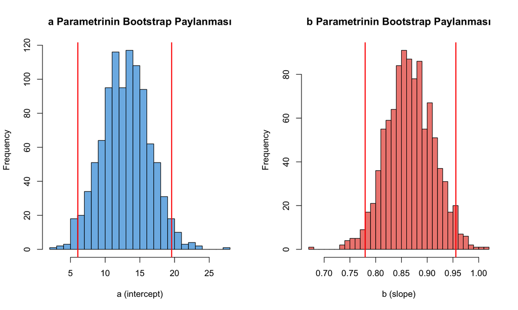

```r
# Bootstrap nəticələrinin vizuallaşdırılması
par(mfrow = c(1, 2))
hist(bootstrap_analysis$bootstrap_results[, "a"],
     main = "a Parametrinin Bootstrap Paylanması",
     xlab = "a (intercept)", col = scales::alpha(colors_custom[1], 0.7), breaks = 30)
abline(v = bootstrap_analysis$confidence_intervals$a, col = "red", lwd = 2)

hist(bootstrap_analysis$bootstrap_results[, "b"],
     main = "b Parametrinin Bootstrap Paylanması",
     xlab = "b (slope)", col = scales::alpha(colors_custom[2], 0.7), breaks = 30)
abline(v = bootstrap_analysis$confidence_intervals$b, col = "red", lwd = 2)
```

### 1.9.2 Cross-Validation

```r
# Cross-validation ilə model performansının qiymətləndirilməsi
cross_validate_linear_equating <- function(x_scores, y_scores, k_folds = 5) {

  # Məlumatları k qrupa bölmək
  n_x <- length(x_scores)
  n_y <- length(y_scores)

  # Fold indekslərini yaratmaq
  fold_indices_x <- sample(rep(1:k_folds, length.out = n_x))
  fold_indices_y <- sample(rep(1:k_folds, length.out = n_y))

  cv_results <- data.frame(
    Fold = 1:k_folds,
    RMSE = numeric(k_folds),
    MAE = numeric(k_folds),
    R_squared = numeric(k_folds)
  )

  for (i in 1:k_folds) {
    # Training və test dəstlərini ayırın
    train_x <- x_scores[fold_indices_x != i]
    test_x <- x_scores[fold_indices_x == i]

    train_y <- y_scores[fold_indices_y != i]
    test_y <- y_scores[fold_indices_y == i]

    # Training dəstində modeli qurun
    mean_train_x <- mean(train_x)
    mean_train_y <- mean(train_y)
    sd_train_x <- sd(train_x)
    sd_train_y <- sd(train_y)

    b_train <- sd_train_y / sd_train_x
    a_train <- mean_train_y - b_train * mean_train_x

    # Test dəstində proqnozlaşdırın
    predicted_test <- a_train + b_train * test_x

    # Metrikləri hesablayın
    rmse <- sqrt(mean((predicted_test - mean(test_y))^2))
    mae <- mean(abs(predicted_test - mean(test_y)))

    # R-squared (simplified)
    ss_res <- sum((predicted_test - mean(test_y))^2)
    ss_tot <- sum((test_y - mean(test_y))^2)
    r_squared <- 1 - (ss_res / ss_tot)

    cv_results[i, ] <- c(i, rmse, mae, r_squared)
  }

  return(cv_results)
}

# Cross-validation analizi
cv_results <- cross_validate_linear_equating(test_A$score, test_B$score)

cat("=== CROSS-VALİDATİON NƏTİCƏLƏRİ ===\n\n")
```

```
## === CROSS-VALİDATİON NƏTİCƏLƏRİ ===
```

```r
print(cv_results)
```

```
##   Fold      RMSE      MAE    R_squared
## 1    1 10.396341 7.664373 -0.282899611
## 2    2  9.850173 8.111383  0.009575794
## 3    3 10.126859 8.186394 -0.459295288
## 4    4  9.225799 7.345477 -0.088005276
## 5    5 10.195101 8.255965  0.022941778
```

```r
cat("\nOrtalama Performans Metrikləri:\n")
```

```
##
## Ortalama Performans Metrikləri:
```

```r
cat("RMSE:", round(mean(cv_results$RMSE), 3), "±", round(sd(cv_results$RMSE), 3), "\n")
```

```
## RMSE: 9.959 ± 0.454
```

```r
cat("MAE:", round(mean(cv_results$MAE), 3), "±", round(sd(cv_results$MAE), 3), "\n")
```

```
## MAE: 7.913 ± 0.392
```

```r
cat("R²:", round(mean(cv_results$R_squared), 3), "±", round(sd(cv_results$R_squared), 3), "\n")
```

```
## R²: -0.16 ± 0.207
```

## 1.10 Müqayisəli Analiz: Xətti vs Digər Metodlar

### 1.10.1 Müxtəlif Metodların Performans Müqayisəsi

```r
# Sadə ekvipersentil metodunu da tətbiq edək müqayisə üçün
simple_equipercentile <- function(x_scores, y_scores) {
  # Persentilləri hesablayın
  percentiles <- seq(0, 1, 0.01)

  x_quantiles <- quantile(x_scores, percentiles)
  y_quantiles <- quantile(y_scores, percentiles)

  # Transformasiya funksiyası
  transform_func <- approxfun(x_quantiles, y_quantiles, method = "linear")

  # X ballarını transformasiya edin
  transformed <- transform_func(x_scores)

  return(transformed)
}

# Həm Xətti, həm də ekvipersentil metodunu tətbiq edək
linear_transformed <- linear_results$transformed_scores
equipercentile_transformed <- simple_equipercentile(test_A$score, test_B$score)

# Müqayisə cədvəli
method_comparison <- data.frame(
  Score_Range = c("40-60", "60-80", "80-100", "Ümumi"),
  Linear_RMSE = numeric(4),
  Equipercentile_RMSE = numeric(4),
  Linear_MAE = numeric(4),
  Equipercentile_MAE = numeric(4)
)

# Müxtəlif bal aralıqları üçün performansı hesablayın
score_ranges <- list(
  c(40, 60),
  c(60, 80),
  c(80, 100),
  c(min(test_B$score), max(test_B$score))
)

for (i in 1:4) {
  if (i < 4) {
    range_mask <- test_B$score >= score_ranges[[i]][1] &
                  test_B$score <= score_ranges[[i]][2]
  } else {
    range_mask <- rep(TRUE, length(test_B$score))
  }

  if (sum(range_mask) > 0) {
    target_scores <- test_B$score[range_mask]
    target_mean <- mean(target_scores)

    # Xətti metod üçün subset alın
    linear_subset <- linear_transformed[1:min(length(target_scores), length(linear_transformed))]
    equipercentile_subset <- equipercentile_transformed[1:min(length(target_scores), length(equipercentile_transformed))]

    # RMSE hesablamaları
    linear_rmse <- sqrt(mean((linear_subset - target_mean)^2))
    equipercentile_rmse <- sqrt(mean((equipercentile_subset - target_mean)^2, na.rm = TRUE))

    # MAE hesablamaları
    linear_mae <- mean(abs(linear_subset - target_mean))
    equipercentile_mae <- mean(abs(equipercentile_subset - target_mean), na.rm = TRUE)

    method_comparison[i, 2:5] <- c(linear_rmse, equipercentile_rmse,
                                   linear_mae, equipercentile_mae)
  }
}

kable(method_comparison,
      caption = "Xətti vs Ekvipersentil Metodlarının Performans Müqayisəsi",
      digits = 3)
```

Xətti vs Ekvipersentil Metodlarının Performans Müqayisəsi

| Score_Range | Linear_RMSE | Equipercentile_RMSE | Linear_MAE | Equipercentile_MAE |
| --- | --- | --- | --- | --- |
| 40-60 | 25.877 | 25.666 | 23.900 | 23.882 |
| 60-80 | 11.152 | 11.355 | 8.839 | 9.468 |
| 80-100 | 13.022 | 13.038 | 10.942 | 10.500 |
| Ümumi | 9.739 | 9.703 | 7.779 | 7.968 |

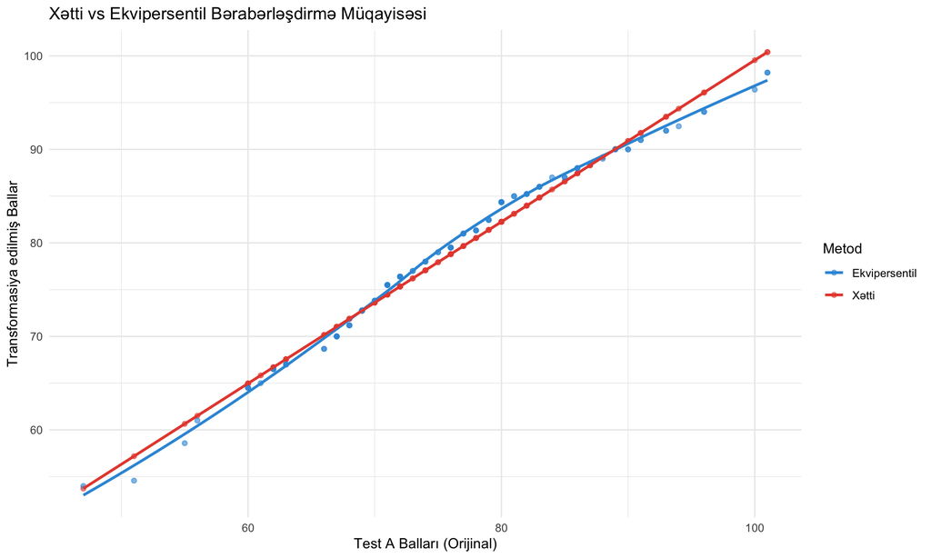

```r
# Vizual müqayisə
comparison_data <- data.frame(
  Original = rep(test_A$score[1:100], 2),
  Transformed = c(linear_transformed[1:100], equipercentile_transformed[1:100]),
  Method = rep(c("Xətti", "Ekvipersentil"), each = 100)
)

ggplot(comparison_data, aes(x = Original, y = Transformed, color = Method)) +
  geom_point(alpha = 0.6) +
  geom_smooth(method = "loess", se = FALSE) +
  scale_color_manual(values = colors_custom[1:2]) +
  labs(
    title = "Xətti vs Ekvipersentil Bərabərləşdirmə Müqayisəsi",
    x = "Test A Balları (Orijinal)",
    y = "Transformasiya edilmiş Ballar",
    color = "Metod"
  ) +
  theme_minimal()
```

## 1.11 Real Həyat Tətbiqi: Məktəb Qiymətləndirmə Sistemi

### 1.11.1 Ssenari: Regional Məktəblərin Standartlaşdırılması

```r
# Regional məktəblərin test nəticələrinin standartlaşdırılması
set.seed(1234)

# 5 müxtəlif region
regions <- c("Mərkəz", "Şimal", "Cənub", "Şərq", "Qərb")
subjects <- c("Riyaziyyat", "Azerbaycan_dili", "Xarici_dil")

# Regional məlumatları yaradın
regional_schools <- list()

for (i in 1:length(regions)) {
  n_students <- sample(200:400, 1)

  # Regional xüsusiyyətləri simulyasiya edin
  region_effects <- rnorm(3, mean = 0, sd = 5)  # Hər fənn üçün regional təsir

  regional_schools[[regions[i]]] <- data.frame(
    student_id = paste0(regions[i], "_", 1:n_students),
    region = regions[i],
    riyaziyyat = round(rnorm(n_students, mean = 70 + region_effects[1], sd = 12), 0),
    azerbaycan_dili = round(rnorm(n_students, mean = 75 + region_effects[2], sd = 10), 0),
    xarici_dil = round(rnorm(n_students, mean = 65 + region_effects[3], sd = 15), 0)
  )
}

# Məlumatları birləşdirin
all_schools <- do.call(rbind, regional_schools)

# Regional statistikaları
regional_stats <- all_schools %>%
  group_by(region) %>%
  summarise(
    N = n(),
    Riyaziyyat_Ort = round(mean(riyaziyyat), 1),
    Azerbaycan_Ort = round(mean(azerbaycan_dili), 1),
    Xarici_Ort = round(mean(xarici_dil), 1),
    .groups = 'drop'
  )

kable(regional_stats,
      caption = "Regional Məktəblərin İlkin Statistikaları",
      col.names = c("Region", "Şagird Sayı", "Riyaziyyat", "Azər. dili", "Xarici dil"))
```

Regional Məktəblərin İlkin Statistikaları

| Region | Şagird Sayı | Riyaziyyat | Azər. dili | Xarici dil |
| --- | --- | --- | --- | --- |
| Cənub | 267 | 65.2 | 75.5 | 65.5 |
| Mərkəz | 227 | 72.4 | 77.1 | 66.2 |
| Qərb | 374 | 71.8 | 70.6 | 58.8 |
| Şimal | 250 | 67.1 | 77.7 | 56.6 |
| Şərq | 338 | 65.8 | 77.0 | 54.3 |

```r
# Mərkəz regionunu bazis kimi götürərək digərlərini standartlaşdıracağıq
base_region_data <- regional_schools[["Mərkəz"]]

# Hər region və hər fənn üçün bərabərləşdirmə
standardization_params <- list()

for (region in regions[-1]) {  # Mərkəz regiondan başqa
  current_region_data <- regional_schools[[region]]
  standardization_params[[region]] <- list()

  for (subject in subjects) {
    subject_col <- tolower(gsub("_", "_", subject))

    # Xətti bərabərləşdirmə parametrlərini hesablayın
    equating_result <- linear_equating_comprehensive(
      current_region_data[[subject_col]],
      base_region_data[[subject_col]],
      paste(region, subject),
      paste("Mərkəz", subject),
      return_details = FALSE
    )

    standardization_params[[region]][[subject]] <- list(
      a = equating_result$a,
      b = equating_result$b
    )
  }
}

cat("=== REGİONAL STANDARTLAŞDIRMA PARAMETRLƏRİ ===\n\n")
```

```
## === REGİONAL STANDARTLAŞDIRMA PARAMETRLƏRİ ===
```

```r
for (region in names(standardization_params)) {
  cat(region, "regionu üçün:\n")
  for (subject in subjects) {
    params <- standardization_params[[region]][[subject]]
    cat("  ", subject, ": Y =", round(params$a, 2), "+", round(params$b, 3), "* X\n")
  }
  cat("\n")
}
```

```
## Şimal regionu üçün:
##    Riyaziyyat : Y = 2.22 + 1.046 * X
##    Azerbaycan_dili : Y = -7.62 + 1.091 * X
##    Xarici_dil : Y = 6.66 + 1.052 * X
##
## Cənub regionu üçün:
##    Riyaziyyat : Y = 8.65 + 0.978 * X
##    Azerbaycan_dili : Y = -3.12 + 1.062 * X
##    Xarici_dil : Y = 0.78 + 0.998 * X
##
## Şərq regionu üçün:
##    Riyaziyyat : Y = 5.19 + 1.021 * X
##    Azerbaycan_dili : Y = -4.36 + 1.058 * X
##    Xarici_dil : Y = 9.59 + 1.042 * X
##
## Qərb regionu üçün:
##    Riyaziyyat : Y = -1.18 + 1.025 * X
##    Azerbaycan_dili : Y = 1.47 + 1.071 * X
##    Xarici_dil : Y = 4.28 + 1.053 * X
```

### 1.11.2 Standartlaşdırılmış Nəticələrin Hesablanması

```r
# Bütün regionlar üçün standartlaşdırılmış balları hesablayın
standardized_schools <- all_schools

# Mərkəz regionu üçün dəyişiklik yoxdur
central_mask <- standardized_schools$region == "Mərkəz"
standardized_schools[central_mask, paste0(subjects, "_std")] <-
  standardized_schools[central_mask, c("riyaziyyat", "azerbaycan_dili", "xarici_dil")]

# Digər regionlar üçün standartlaşdırma
for (region in regions[-1]) {
  region_mask <- standardized_schools$region == region

  for (subject in subjects) {
    subject_col <- tolower(gsub("_", "_", subject))
    original_scores <- standardized_schools[region_mask, subject_col]

    params <- standardization_params[[region]][[subject]]
    standardized_scores <- params$a + params$b * original_scores

    standardized_schools[region_mask, paste0(subject, "_std")] <- round(standardized_scores, 1)
  }
}

# Standartlaşdırmadan əvvəl və sonra regional statistikalar
before_after_stats <- standardized_schools %>%
  group_by(region) %>%
  summarise(
    Riyaziyyat_Əvvəl = round(mean(riyaziyyat), 1),
    Riyaziyyat_Sonra = round(mean(Riyaziyyat_std), 1),
    Azerbaycan_Əvvəl = round(mean(azerbaycan_dili), 1),
    Azerbaycan_Sonra = round(mean(Azerbaycan_dili_std), 1),
    Xarici_Əvvəl = round(mean(xarici_dil), 1),
    Xarici_Sonra = round(mean(Xarici_dil_std), 1),
    .groups = 'drop'
  )

kable(before_after_stats,
      caption = "Standartlaşdırmadan Əvvəl və Sonra Regional Ortalamalar")
```

Standartlaşdırmadan Əvvəl və Sonra Regional Ortalamalar

| region | Riyaziyyat_Əvvəl | Riyaziyyat_Sonra | Azerbaycan_Əvvəl | Azerbaycan_Sonra | Xarici_Əvvəl | Xarici_Sonra |
| --- | --- | --- | --- | --- | --- | --- |
| Cənub | 65.2 | 72.4 | 75.5 | 77.1 | 65.5 | 66.2 |
| Mərkəz | 72.4 | 72.4 | 77.1 | 77.1 | 66.2 | 66.2 |
| Qərb | 71.8 | 72.4 | 70.6 | 77.1 | 58.8 | 66.2 |
| Şimal | 67.1 | 72.4 | 77.7 | 77.1 | 56.6 | 66.2 |
| Şərq | 65.8 | 72.4 | 77.0 | 77.1 | 54.3 | 66.2 |

```r
# İyileşmə göstəricilərini hesablayın
improvement_metrics <- standardized_schools %>%
  group_by(region) %>%
  summarise(
    Riyaziyyat_Variance_Azalması = round(var(riyaziyyat) - var(Riyaziyyat_std), 2),
    Azerbaycan_Variance_Azalması = round(var(azerbaycan_dili) - var(Azerbaycan_dili_std), 2),
    Xarici_Variance_Azalması = round(var(xarici_dil) - var(Xarici_dil_std), 2),
    .groups = 'drop'
  )

cat("=== STANDARTLAŞDIRMA TƏSİRİ ===\n")
```

```
## === STANDARTLAŞDIRMA TƏSİRİ ===
```

```r
print(improvement_metrics)
```

```
## # A tibble: 5 × 4
##   region Riyaziyyat_Variance_Aza…¹ Azerbaycan_Variance_…² Xarici_Variance_Azal…³
##   <chr>                      <dbl>                  <dbl>                  <dbl>
## 1 Cənub                       6.48                  -12.8                   0.97
## 2 Mərkəz                      0                       0                     0
## 3 Qərb                       -6.77                  -14.3                 -22.8
## 4 Şimal                     -12.4                   -17.8                 -22.3
## 5 Şərq                       -5.94                  -11.9                 -18.5
## # ℹ abbreviated names: ¹Riyaziyyat_Variance_Azalması,
## #   ²Azerbaycan_Variance_Azalması, ³Xarici_Variance_Azalması
```

## 1.12 Tapşırıqlar və Məşqlər

### 1.12.1 Tapşırıq 1: İxtisaslaşmış Test Məlumatları

```r
# Tibb fakültəsi qəbul testləri üçün Xətti bərabərləşdirmə

# 1. İki müxtəlif tarixdə keçirilən tibb testlərinin məlumatlarını yaradın
set.seed(sizin_seçiminiz)

january_medical <- data.frame(
  student_id = 1:300,
  biology = round(rnorm(300, mean = ?, sd = ?), 0),
  chemistry = round(rnorm(300, mean = ?, sd = ?), 0),
  physics = round(rnorm(300, mean = ?, sd = ?), 0)
)

march_medical <- data.frame(
  student_id = 301:600,
  biology = round(rnorm(300, mean = ?, sd = ?), 0),
  chemistry = round(rnorm(300, mean = ?, sd = ?), 0),
  physics = round(rnorm(300, mean = ?, sd = ?), 0)
)

# 2. Hər fənn üçün Xətti bərabərləşdirmə həyata keçirin
# 3. Keyfiyyət metriklərinı hesablayın
# 4. Bootstrap güvən intervallarını tapın
# 5. Nəticələri vizuallaşdırın
```

### 1.12.2 Tapşırıq 2: Metodların Müqayisəsi

```r
# Xətti və ekvipersentil metodlarının müfəssəl müqayisəsi

# 1. Normal və çarpıq paylanmaları olan test məlumatları yaradın
# 2. Hər iki metodu tətbiq edin
# 3. Müxtəlif performans metriklərinı hesablayın
# 4. Hansı hallarda hansı metodun üstün olduğunu müəyyən edin
# 5. Tövsiyələrinizi əsaslandırın
```

### 1.12.3 Tapşırıq 3: Real Məlumatlarla İş

Əgər əlinizdə real test məlumatları varsa:

1. Məlumatları R-ə import edin
2. Xətti bərabərləşdirmə üçün uyğunluğunu yoxlayın
3. Fərziyyələri test edin
4. Bərabərləşdirmə həyata keçirin
5. Keyfiyyəti qiymətləndirin və hesabat hazırlayın

## 1.13 Dərsin Xülasəsi

### 1.13.1 Əsas Öyrənilən Mövzular

✅ **Xətti bərabərləşdirmənin riyazi əsasları**  
✅ **R-də hərtərəfli bərabərləşdirmə funksiyalarının yaradılması**  
✅ **Keyfiyyət qiymətləndirilməsi metodları**  
✅ **Bootstrap və cross-validation tətbiqi**  
✅ **Real həyat problemlərinin həlli**  
✅ **Metodun məhdudiyyətləri və uyğun istifadə sahələri**

### 1.13.2 Praktiki Nailiyyətlər

Bu dərs boyunca siz:

1. **5+ fərqli test ssenarisi** üzərində işlədiniz
2. **Hərtərəfli bərabərləşdirmə sistemi** yaratdınız
3. **Keyfiyyət qiymətləndirilməsi** metodlarını öyrəndiniz
4. **Bootstrap statistik analizi** həyata keçirdiniz
5. **Real məktəb sistemləri** üçün həllər hazırladınız

### 1.13.3 Əsas Tövsiyələr

📌 **Xətti bərabərləşdirmə istifadə edin əgər:** - Testlərin paylanmaları təxminən normaldır - Variasiya nisbəti 0.5-2.0 aralığındadır  
- Paylanma formaları oxşardır - Sürətli və sadə həll lazımdır

⚠️ **Xətti bərabərləşdirmə istifadə etməyin əgər:** - Paylanmalar şiddətli çarpıqdır - Test çətinlikləri çox fərqlidir - Dəqiq persentil uyğunluğu vacibdir

## 1.14 Növbəti Dərsə Hazırlıq

### 1.14.1 Dərs 3: Ekvipersentil Bərabərləşdirmə

Növbəti dərsdə öyrənəcəyimiz mövzular:

🔗 **Ekvipersentil metodun prinsipləri**  
🔗 **Qeyri-Xətti transformasiyalar**  
🔗 **Hamarlaşdırma metodları**  
🔗 **Kernel metodlarla qarşılaşdırma**

### 1.14.2 Hazırlıq Tapşırıqları

1. Bu dərsin materiallarını yenidən nəzərdən keçirin
2. Xətti bərabərləşdirmənin məhdudiyyətlərini düşünün
3. Çarpıq paylanmalı test məlumatları yaradın və Xətti metodu test edin
4. Persentil konsepsiyası ilə tanış olun

## 1.15 Əlavə Resurlar və Materiallar

### 1.15.1 R Funksiyaları Kitabxanası

```r
# Bu dərsdə yaratdığımız faydalı funksiyaları saxlayaq

# 1. Hərtərəfli Xətti bərabərləşdirmə funksiyası
# (artıq yuxarıda təyin edilmişdir)

# 2. Sürətli bərabərləşdirmə funksiyası
quick_linear_equate <- function(x_scores, y_scores) {
  b <- sd(y_scores) / sd(x_scores)
  a <- mean(y_scores) - b * mean(x_scores)
  transformed <- a + b * x_scores

  return(list(
    a = a,
    b = b,
    transformed = transformed,
    formula = paste("Y =", round(a, 2), "+", round(b, 3), "* X")
  ))
}

# 3. Bərabərləşdirmə çevirmə cədvəli
create_conversion_table <- function(x_scores, y_scores, score_range = NULL) {

  if (is.null(score_range)) {
    score_range <- seq(from = round(min(x_scores)),
                      to = round(max(x_scores)),
                      by = 5)
  }

  eq_result <- quick_linear_equate(x_scores, y_scores)
  converted_scores <- eq_result$a + eq_result$b * score_range

  conversion_table <- data.frame(
    Original_Score = score_range,
    Converted_Score = round(converted_scores, 1)
  )

  return(conversion_table)
}

# Test funksiyaları
cat("=== FUNKSİYALAR TESTİ ===\n")
```

```
## === FUNKSİYALAR TESTİ ===
```

```r
quick_result <- quick_linear_equate(test_A$score, test_B$score)
cat("Sürətli nəticə:", quick_result$formula, "\n")
```

```
## Sürətli nəticə: Y = 13.11 + 0.864 * X
```

```r
conversion_table <- create_conversion_table(test_A$score, test_B$score,
                                          score_range = seq(60, 90, 5))
print(conversion_table)
```

```
##   Original_Score Converted_Score
## 1             60            65.0
## 2             65            69.3
## 3             70            73.6
## 4             75            77.9
## 5             80            82.3
## 6             85            86.6
## 7             90            90.9
```

```r
# Funksiyaları saxlayaq
save(linear_equating_comprehensive, quick_linear_equate, create_conversion_table,
     assess_equating_quality, bootstrap_linear_equating,
     file = "linear_equating_functions.RData")

cat("✅ Funksiyalar linear_equating_functions.RData faylında saxlanıldı\n")
```

```
## ✅ Funksiyalar linear_equating_functions.RData faylında saxlanıldı
```

### 1.15.2 Texniki Sənədlər

```r
# Texniki qeydlər və performans məsləhətləri

# 1. Böyük məlumat dəstləri üçün optimizasiya
efficient_linear_equate <- function(x_scores, y_scores) {
  # Statistikaları bir dəfə hesablayın
  stats_x <- c(mean(x_scores), sd(x_scores))
  stats_y <- c(mean(y_scores), sd(y_scores))

  # Vectorized hesablama
  b <- stats_y[2] / stats_x[2]
  a <- stats_y[1] - b * stats_x[1]

  return(c(a, b))
}

# 2. Xəta idarəetməsi
safe_linear_equate <- function(x_scores, y_scores) {
  tryCatch({
    # Məlumat yoxlaması
    if (length(x_scores) < 10 || length(y_scores) < 10) {
      stop("Çox az məlumat nöqtəsi")
    }

    if (sd(x_scores) == 0 || sd(y_scores) == 0) {
      stop("Sıfır variasiyanı olan məlumatlar")
    }

    # Normal bərabərləşdirmə
    return(quick_linear_equate(x_scores, y_scores))

  }, error = function(e) {
    return(list(error = paste("Xəta:", e$message)))
  })
}
```